# Homework_5

Justin Rigby

5 March 2018

1. cd /home/justin/Desktop/graduateschoolclasses/Winter_2018/Evolution_of_Biological_Molecules/HW5/data  
   load TEM1-imipenem-from-1BT5.pse  
   hide everything  
   bg_color white  
   show cartoon, TEM-1  
   show cartoon, imipenem  
   color gray70, TEM-1  
   color black, imipenem  
   cd ../src  
   python getRelativeSolventAccessibility.py

8 Residues  
35, 126, 134, 135, 187, 232, 248, and 249.

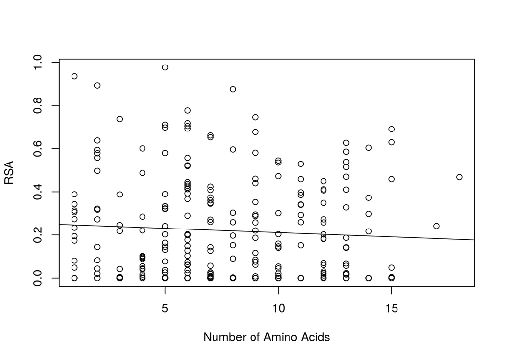

```
## integer(0)
```

```r
site.diversity <- read.delim("~/Desktop/graduateschoolclasses/Winter_2018/Evolution_of_Biological_Molecules/HW5/data/site-diversity.txt", comment.char="#")

solvent <- read.delim("~/Desktop/graduateschoolclasses/Winter_2018/Evolution_of_Biological_Molecules/HW5/solvent.txt")

RSA <- solvent$rsa
num_aa <- site.diversity$num.aas

plot(num_aa, RSA, xlab= "Number of Amino Acids") + abline(lm(RSA ~ num_aa))
```

```r
cor.test(num_aa, RSA, method = 'spearman')
```

```
##
##  Spearman's rank correlation rho
##
## data:  num_aa and RSA
## S = 2905300, p-value = 0.2258
## alternative hypothesis: true rho is not equal to 0
## sample estimates:
##         rho
## -0.07642456
```

From the results we can see that there is not a correlation between the amino acid diversity at a site and the amount of solvent accesibly the residue is exposed to. Evolutionarily speaking, there is no relationship between the rate of amino acid changes and the expouser to solvent in the cell.

4. This relationship may exist soley by the fact that these sites may not be influenced by the solvent exposer level enough to warrant a selection for specific amino acids, and may instead just change because of neutral evolution.
2. Residues  
   44, 45, 46, 47, 48, 49, 50, 57, 58, 59, 60, 230, 231, 232, 233, 234, 235, 236, 237, 238, 240, 243, 244, 245, 246, 247, 248, 249, 250, 251, 258, 259, 260, 261, 262, 263, 264, 265

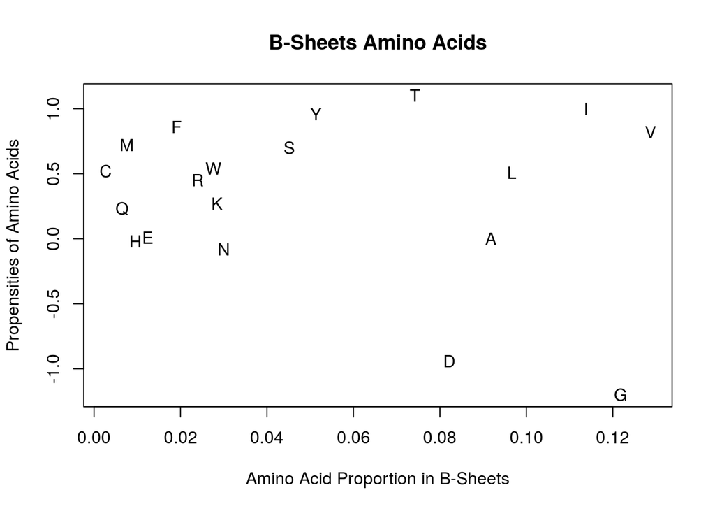

```r
minor.sheet.propensities <- read.delim("~/Desktop/graduateschoolclasses/Winter_2018/Evolution_of_Biological_Molecules/HW5/data/minor-sheet-propensities.txt",fill = TRUE, comment.char="#")
#Residues of the Beta Sheets in TEM-1
b_sheet_resi <- c(44, 45, 46, 47, 48, 49, 50, 57, 58, 59, 60, 230, 231, 232, 233, 234, 235, 236, 237, 238, 240, 243, 244, 245, 246, 247, 248, 249, 250, 251, 258, 259, 260, 261, 262, 263, 264, 265)

#Single letter amino acid
aas = c("A", "C", "D", "E", "F", "G", "H", "I", "K", "L", "M", "N", "P", "Q", "R", "S", "T", "V", "W", "Y")

#Reading the proportions of amino acids at each site in the protein
aaprop <- read.table('/home/justin/Desktop/graduateschoolclasses/Winter_2018/Evolution_of_Biological_Molecules/HW5/data/site-aa-proportion.txt', header = T)

#Matching the amino acid proportions found at each residue in the beta sheets
aaprop.sheets <- aaprop[match(b_sheet_resi, aaprop$site),]
#Determining the mean value of each of the amino acids in beta sheets from the matched vector
mean.aaprop.sheets <- colMeans(aaprop.sheets, na.rm = T)

#Plotting the proportion of amino acids in beta sheets
plot(mean.aaprop.sheets[2:21], minor.sheet.propensities$ddg, pch = aas, xlab = "Amino Acid Proportion in B-Sheets", ylab = 'Propensities of Amino Acids', main = 'B-Sheets Amino Acids')
```

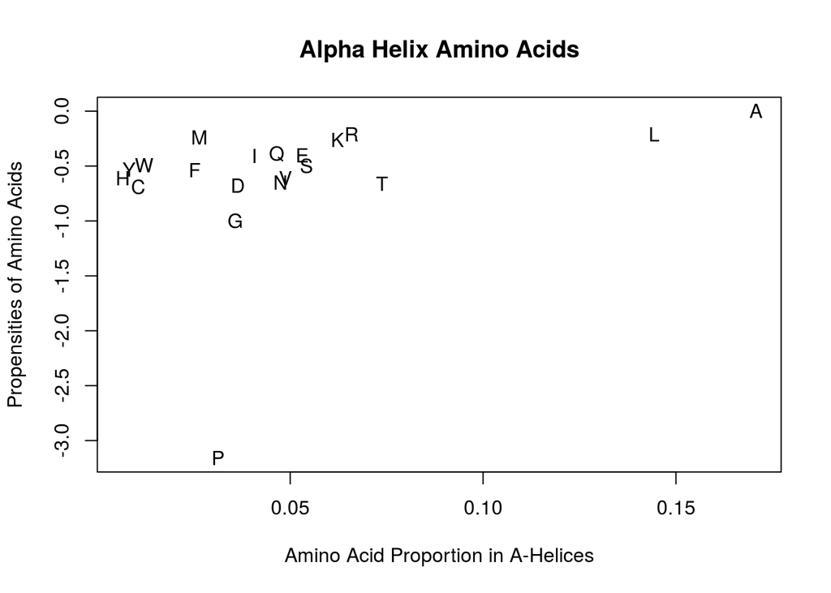

```r
helix_propensities <- read.delim("~/Desktop/graduateschoolclasses/Winter_2018/Evolution_of_Biological_Molecules/HW5/data/pace-helix-propensities.txt", fill = TRUE)

a_helix_resi <- c(27,28,29,30,31,32,33,34,35,36,37,38,39,40,70,71,72,73,74,75,76,77,78,79,80,81,82,83,84,85,86,99,100,101,108,109,110,111,119,120,121,122,123,124,125,126,127,128,132,133,134,135,136,137,138,139,140,141,142,145,146,147,148,149,150,151,152,153,154,155,167,168,169,170,183,184,185,186,187,188,189,190,191,192,193,194,195,201,202,203,204,205,206,207,208,209,210,211,212,213,221,222,223,224,272,273,274,275,276,277,278,279,280,281,282,283,284,285,286,287,288,289)

#Single letter amino acid
aas = c("A", "C", "D", "E", "F", "G", "H", "I", "K", "L", "M", "N", "P", "Q", "R", "S", "T", "V", "W", "Y")

#Reading the proportions of amino acids at each site in the protein
aaprop <- read.table('/home/justin/Desktop/graduateschoolclasses/Winter_2018/Evolution_of_Biological_Molecules/HW5/data/site-aa-proportion.txt', header = T)

#Matching the amino acid proportions found at each residue in the alpha helices
aaprop.helix <- aaprop[match(a_helix_resi, aaprop$site),]
#Determining the mean value of each of the amino acids in beta sheets from the matched vector
mean.aaprop.helix <- colMeans(aaprop.helix, na.rm = T)

#Plotting the proportion of amino acids in beta sheets
plot(mean.aaprop.helix[2:21], helix_propensities$ddg, pch = aas, xlab = "Amino Acid Proportion in A-Helices", ylab = 'Propensities of Amino Acids', main = 'Alpha Helix Amino Acids')
```

3. Between both graphs, the graph which shows the best indication of the propensities and amino acid proportions is the alpha helix one. We can see that the TEM-1 protein is enriched for Alanine in the alpha helix alongside Leucine. However the other common amino acids seen in alpha helices (Arginine and Methonine) do not seem to be in great numbers in the graph and cluster on the lower proportion size.

$\Delta G_u = 5 \frac{kcal}{mol}$  
$\Delta G = -RTln(K_{eq})=> K_{eq} = e^{-\frac{\Delta G}{RT}}$

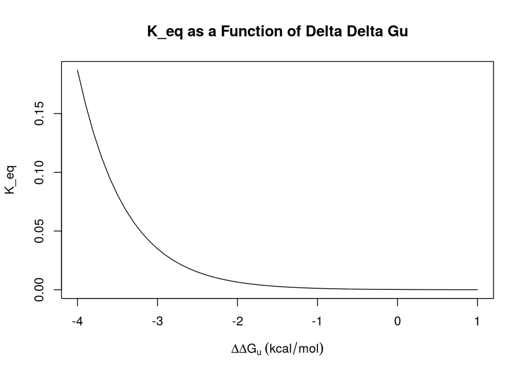

```r
dd_gu <- seq(-4, 1, by = 0.1)

k_eq <- function(dd_gu){

k_eqs <- exp(-(5+dd_gu)/0.5961611)
return(k_eqs)
}

k_eq_results <- k_eq(dd_gu)

plot(dd_gu, k_eq_results, type = 'l', xlab = expression(Delta*Delta*G[u]~(kcal/mol)), ylab = 'K_eq', main = 'K_eq as a Function of Delta Delta Gu')
```

$\beta = \alpha [P]_0 k_{cat = 1 h^-1}$  
$r = \alpha [P]_0 Pr_{fold}k_{cat} \Delta G_u = \beta Pr_{fold}(\Delta G_u)$

$Pr_{fold} = r = s = \frac{1}{1+e^{-\frac{\Delta G*\Delta \Delta G_{u D->E}}{RT}}}$

$s_{D->E]} = r_D - r_E $

b/c)

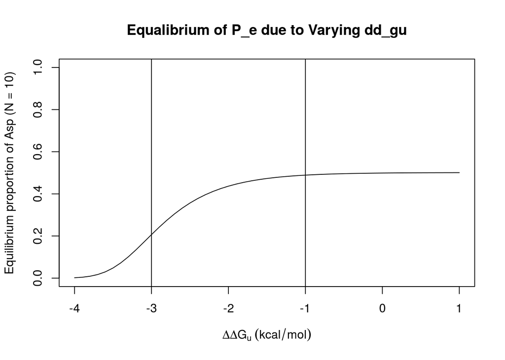

```
## integer(0)
```

```r
#Definning Variables

d_gu <- 5
  dd_gu <- seq(-4, 1, by = 0.1)
    N10 = 10
      N100 = 100
        N1000 = 1000

#Calculating the Selection Coefficent for each itteration of dd_gu
s_i <- function (d_gu, dd_gu){
s_u <- (1-
  (1)/
    (1+exp(-(d_gu+dd_gu)/(0.5961611)

      )))
return(s_u)
}

s_r <- s_i(d_gu, 0)
  s_e <- s_i(d_gu, dd_gu)
    s_de <- s_r - s_e

pi <- function(N, s_r){

pi_e <- (exp(2*N*(s_de)))/(exp(2*N*(s_e))+exp(2*N*(s_r)))
return(pi_e)
}
pi_e10 <- pi(N10, s_de)
  pi_e100 <- pi(N100, s_de)
    pi_e1000 <- pi(N1000, s_de)

plot(dd_gu, pi_e10, type = "l", xlab =expression(Delta*Delta*G[u]~(kcal/mol)), ylab = 'Equilibrium proportion of Asp (N = 10)', main = 'Equalibrium of P_e due to Varying dd_gu', xlim = c(-4, 1), ylim = c(0,1)) +abline(v=-1) + abline(v=-3)
```

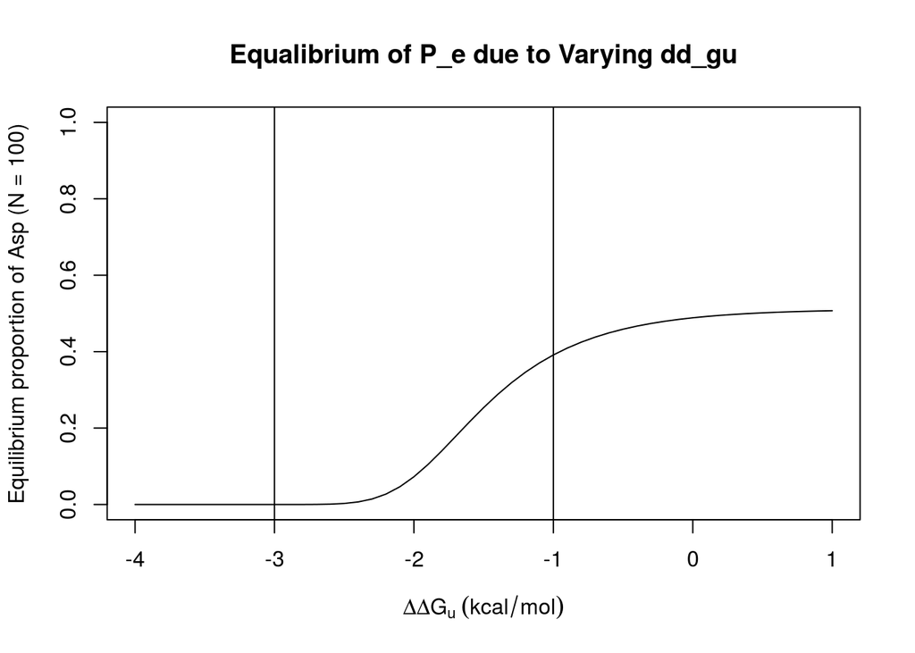

```
## integer(0)
```

```r
plot(dd_gu, pi_e100, type = "l", xlab =expression(Delta*Delta*G[u]~(kcal/mol)), ylab = 'Equilibrium proportion of Asp (N = 100)', main = 'Equalibrium of P_e due to Varying dd_gu', xlim = c(-4, 1), ylim = c(0,1)) +abline(v=-1) + abline(v=-3)
```

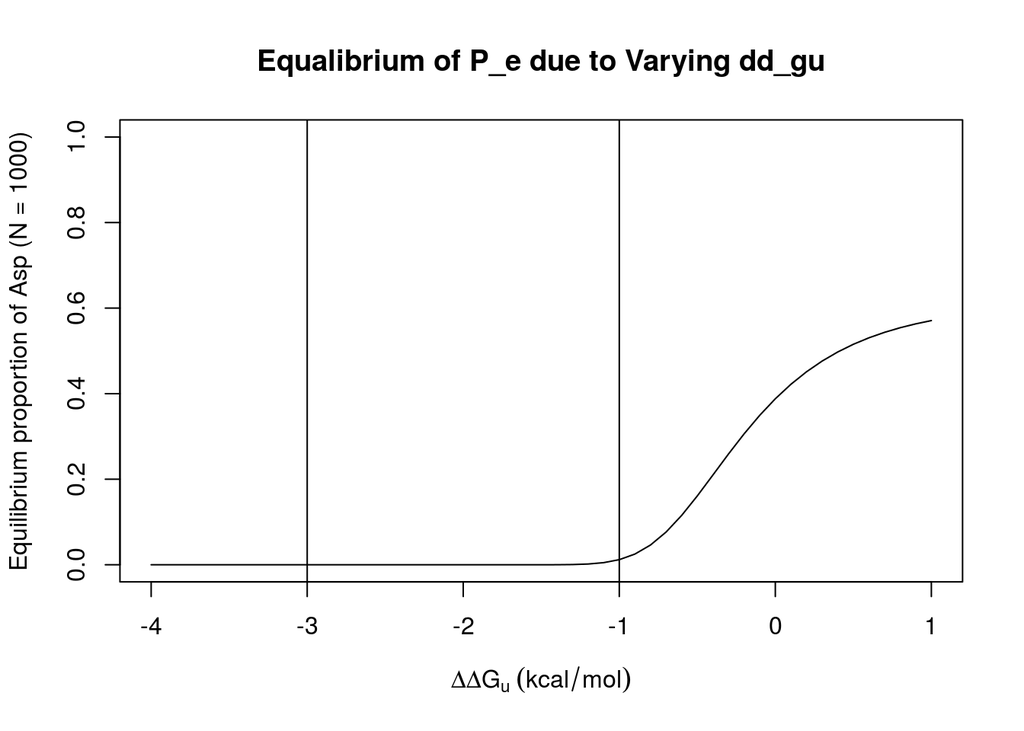

```
## integer(0)
```

```r
plot(dd_gu, pi_e1000, type = "l", xlab =expression(Delta*Delta*G[u]~(kcal/mol)), ylab = 'Equilibrium proportion of Asp (N = 1000)', main = 'Equalibrium of P_e due to Varying dd_gu', xlim = c(-4, 1), ylim = c(0,1)) +abline(v=-1) + abline(v=-3)
```

The curves in these graphs are indicating that in smaller populations the chances of having a protein which is favourable to be in an unfolded state is higher. This is probably just due to small population effects skewing the results because in the large populations we tend to see proteins which are more likely to be in a folded state to be ata higher frequency.